# Отчет по домашней работе №2

Расчёт сети Fast Ethernet

Виноградова М.А

Российский университет дружбы народов, Москва, Россия

25 сентября 2025

# Информация

## Докладчик

- Виноградова Мария Андреевна
- студентка НПИбд-02-24
- номер студ. билета 1132240691
- Российский университет дружбы народов
- 1132240691@pfur.ru
- https://github.com/mavinogradova/study_2025-2026_os2

# Цель работы

Изучение принципов технологий Ethernet и Fast Ethernet и практическое освоение методик оценки работоспособности сети, построенной на базе технологии Fast Ethernet.

# Задание

Требуется оценить работоспособность 100-мегабитной сети Fast Ethernet в соответствии с первой и второй моделями.

# Выполнение домашней работы

# Алгоритм расчёта моделей

## Перед выполнением расчётов необходимо чётко определить порядок действий для каждой модели.

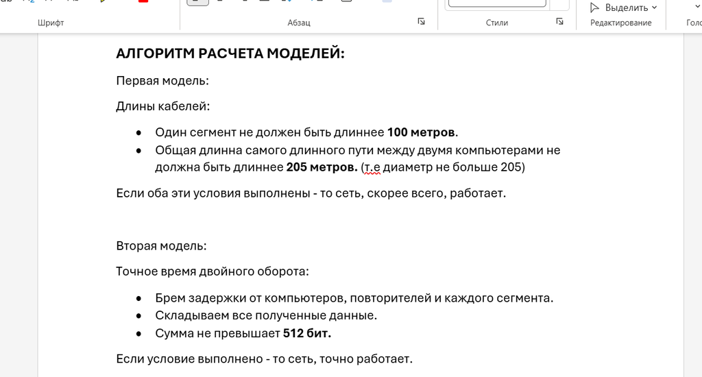

Алгоритм расчёта моделей

# Теоретические сведения о моделях

## Подтверждение информации о первой и второй моделях Fast Ethernet из методички.

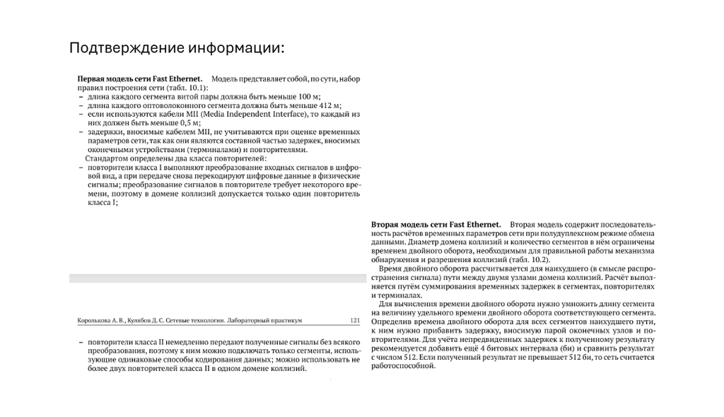

Подтверждение информации о моделях

# Данные, необходимые для расчётов

## Используем сводные данные: длины сегментов для всех шести вариантов и константы для второй модели.

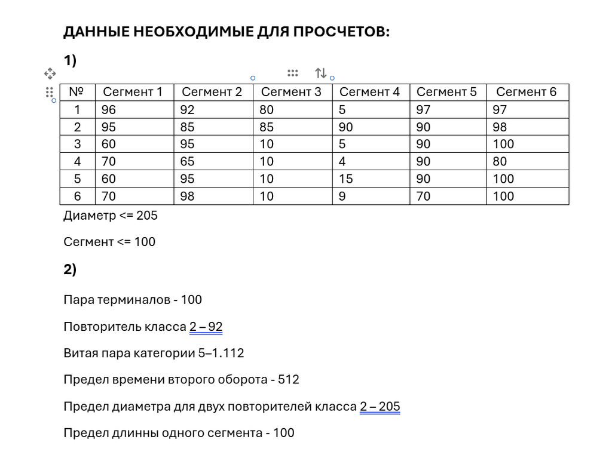

Данные, необходимые для просчётов

# Варианты заданий

## Конфигурации сети для шести вариантов представлены в табл. 10.4.

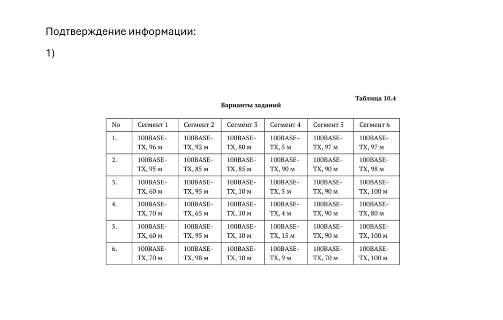

Варианты заданий (Таблица 10.4)

# Предельные параметры и временные задержки

## Предельно допустимый диаметр домена коллизий (табл. 10.1) и временные задержки компонентов сети Fast Ethernet (табл. 10.2).

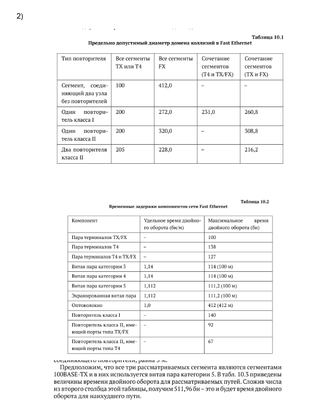

Таблицы 10.1 и 10.2

# Расчёт первой модели

## Для каждого варианта определим самый длинный путь между двумя наиболее удалёнными узлами и вычислим диаметр домена коллизий.

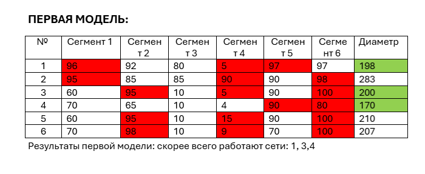

Результаты первой модели

# Расчёт второй модели

## Для второй модели используем данные из табл. 10.2 и рассчитываем время двойного оборота для наихудшего пути каждого варианта.

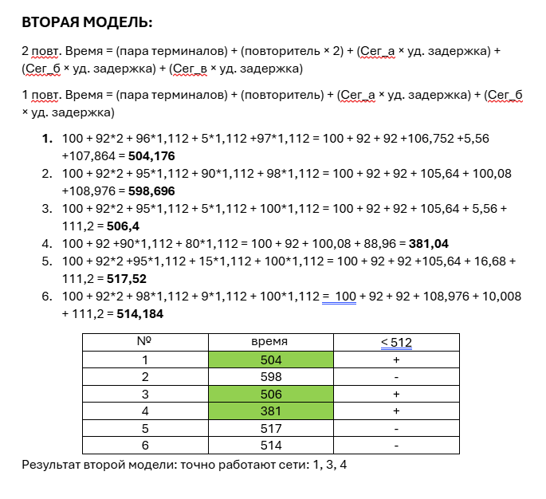

Результаты второй модели

# Общий вывод

## Общий результат по обеим моделям.

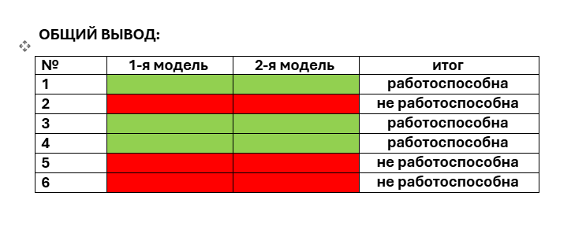

Общий вывод

## Итоговая таблица показывает, что варианты 1, 3 и 4 работоспособны по обеим моделям, а варианты 2, 5 и 6 — неработоспособны.

# Выводы

В ходе домашней работы были изучены принципы технологий Ethernet и Fast Ethernet, а также освоены методики оценки работоспособности сети Fast Ethernet. Для шести вариантов конфигурации сети были выполнены расчёты по первой и второй моделям. По первой модели проверялись длины сегментов и диаметр домена коллизий; по второй — время двойного оборота. В результате варианты 1, 3 и 4 оказались работоспособными, а варианты 2, 5 и 6 — неработоспособными из-за превышения допустимого диаметра и времени двойного оборота.